# Risk Factor Analysis

## Outcome Variable

**Outcome Variable:** whz

## Predictor Variables

**Intervention Variable:** impfloor

**Adjustment Set:**

- arm
- sex
- W_mage
- meducyrs
- feducyrs
- hhwealth_quart
- hfoodsec
- W_mhtcm
- W_mwtkg
- W_mbmi
- W_nrooms
- W_nchldlt5
- W_parity
- impsan
- safeh20
- delta_W_mage
- delta_meducyrs
- delta_feducyrs
- delta_hhwealth_quart
- delta_hfoodsec
- delta_W_mhtcm
- delta_W_mwtkg
- delta_W_mbmi
- delta_W_nrooms
- delta_W_nchldlt5
- delta_W_parity
- delta_impsan
- delta_safeh20

## Stratifying Variables

The analysis was stratified on these variable(s):

- agecat
- studyid
- country

## Data Summary

| agecat | studyid | country | impfloor | n_cell | n |
| --- | --- | --- | --- | --- | --- |
| Birth | CMC-V-BCS-2002 | INDIA | 1 | 68 | 68 |
| Birth | CMC-V-BCS-2002 | INDIA | 0 | 0 | 68 |
| Birth | CONTENT | PERU | 1 | 2 | 2 |
| Birth | CONTENT | PERU | 0 | 0 | 2 |
| Birth | GMS-Nepal | NEPAL | 1 | 97 | 503 |
| Birth | GMS-Nepal | NEPAL | 0 | 406 | 503 |
| Birth | IRC | INDIA | 1 | 253 | 253 |
| Birth | IRC | INDIA | 0 | 0 | 253 |
| Birth | JiVitA-3 | BANGLADESH | 1 | 1215 | 17966 |
| Birth | JiVitA-3 | BANGLADESH | 0 | 16751 | 17966 |
| Birth | JiVitA-4 | BANGLADESH | 1 | 271 | 2394 |
| Birth | JiVitA-4 | BANGLADESH | 0 | 2123 | 2394 |
| Birth | MAL-ED | BANGLADESH | 1 | 185 | 201 |
| Birth | MAL-ED | BANGLADESH | 0 | 16 | 201 |
| Birth | MAL-ED | BRAZIL | 1 | 55 | 57 |
| Birth | MAL-ED | BRAZIL | 0 | 2 | 57 |
| Birth | MAL-ED | INDIA | 1 | 33 | 39 |
| Birth | MAL-ED | INDIA | 0 | 6 | 39 |
| Birth | MAL-ED | NEPAL | 1 | 8 | 24 |
| Birth | MAL-ED | NEPAL | 0 | 16 | 24 |
| Birth | MAL-ED | PERU | 1 | 37 | 210 |
| Birth | MAL-ED | PERU | 0 | 173 | 210 |
| Birth | MAL-ED | SOUTH AFRICA | 1 | 86 | 95 |
| Birth | MAL-ED | SOUTH AFRICA | 0 | 9 | 95 |
| Birth | MAL-ED | TANZANIA, UNITED REPUBLIC OF | 1 | 5 | 111 |
| Birth | MAL-ED | TANZANIA, UNITED REPUBLIC OF | 0 | 106 | 111 |
| Birth | NIH-Birth | BANGLADESH | 1 | 505 | 572 |
| Birth | NIH-Birth | BANGLADESH | 0 | 67 | 572 |
| Birth | NIH-Crypto | BANGLADESH | 1 | 542 | 707 |
| Birth | NIH-Crypto | BANGLADESH | 0 | 165 | 707 |

[output cut: 66 more lines]

The following strata were considered:

- agecat: 24 months, studyid: CMC-V-BCS-2002, country: INDIA
- agecat: 24 months, studyid: CONTENT, country: PERU
- agecat: 24 months, studyid: GMS-Nepal, country: NEPAL
- agecat: 24 months, studyid: IRC, country: INDIA
- agecat: 24 months, studyid: JiVitA-3, country: BANGLADESH
- agecat: 24 months, studyid: JiVitA-4, country: BANGLADESH
- agecat: 24 months, studyid: MAL-ED, country: BANGLADESH
- agecat: 24 months, studyid: MAL-ED, country: BRAZIL
- agecat: 24 months, studyid: MAL-ED, country: INDIA
- agecat: 24 months, studyid: MAL-ED, country: NEPAL
- agecat: 24 months, studyid: MAL-ED, country: PERU
- agecat: 24 months, studyid: MAL-ED, country: SOUTH AFRICA
- agecat: 24 months, studyid: MAL-ED, country: TANZANIA, UNITED REPUBLIC OF
- agecat: 24 months, studyid: NIH-Birth, country: BANGLADESH
- agecat: 24 months, studyid: NIH-Crypto, country: BANGLADESH
- agecat: 24 months, studyid: PROVIDE, country: BANGLADESH
- agecat: 6 months, studyid: CMC-V-BCS-2002, country: INDIA
- agecat: 6 months, studyid: CONTENT, country: PERU
- agecat: 6 months, studyid: GMS-Nepal, country: NEPAL
- agecat: 6 months, studyid: IRC, country: INDIA
- agecat: 6 months, studyid: JiVitA-3, country: BANGLADESH
- agecat: 6 months, studyid: JiVitA-4, country: BANGLADESH
- agecat: 6 months, studyid: MAL-ED, country: BANGLADESH
- agecat: 6 months, studyid: MAL-ED, country: BRAZIL
- agecat: 6 months, studyid: MAL-ED, country: INDIA
- agecat: 6 months, studyid: MAL-ED, country: NEPAL
- agecat: 6 months, studyid: MAL-ED, country: PERU
- agecat: 6 months, studyid: MAL-ED, country: SOUTH AFRICA
- agecat: 6 months, studyid: MAL-ED, country: TANZANIA, UNITED REPUBLIC OF
- agecat: 6 months, studyid: NIH-Birth, country: BANGLADESH
- agecat: 6 months, studyid: NIH-Crypto, country: BANGLADESH
- agecat: 6 months, studyid: PROVIDE, country: BANGLADESH
- agecat: Birth, studyid: CMC-V-BCS-2002, country: INDIA
- agecat: Birth, studyid: CONTENT, country: PERU
- agecat: Birth, studyid: GMS-Nepal, country: NEPAL
- agecat: Birth, studyid: IRC, country: INDIA
- agecat: Birth, studyid: JiVitA-3, country: BANGLADESH
- agecat: Birth, studyid: JiVitA-4, country: BANGLADESH
- agecat: Birth, studyid: MAL-ED, country: BANGLADESH
- agecat: Birth, studyid: MAL-ED, country: BRAZIL
- agecat: Birth, studyid: MAL-ED, country: INDIA
- agecat: Birth, studyid: MAL-ED, country: NEPAL
- agecat: Birth, studyid: MAL-ED, country: PERU
- agecat: Birth, studyid: MAL-ED, country: SOUTH AFRICA
- agecat: Birth, studyid: MAL-ED, country: TANZANIA, UNITED REPUBLIC OF
- agecat: Birth, studyid: NIH-Birth, country: BANGLADESH
- agecat: Birth, studyid: NIH-Crypto, country: BANGLADESH
- agecat: Birth, studyid: PROVIDE, country: BANGLADESH

### Dropped Strata

- agecat: Birth, studyid: CMC-V-BCS-2002, country: INDIA
- agecat: Birth, studyid: CONTENT, country: PERU
- agecat: Birth, studyid: IRC, country: INDIA
- agecat: Birth, studyid: MAL-ED, country: BRAZIL
- agecat: 6 months, studyid: CMC-V-BCS-2002, country: INDIA
- agecat: 6 months, studyid: IRC, country: INDIA
- agecat: 6 months, studyid: MAL-ED, country: BRAZIL
- agecat: 24 months, studyid: CMC-V-BCS-2002, country: INDIA
- agecat: 24 months, studyid: IRC, country: INDIA
- agecat: 24 months, studyid: MAL-ED, country: BRAZIL

## Methods Detail

We’re interested in the causal parameters $E[Y_a]$ for all values of $a \in \mathcal{A}$. These parameters represent the mean outcome if, possibly contrary to fact, we intervened to set all units to have $A=a$. Under the randomization and positivity assumptions, these are identified by the statistical parameters $\psi_a=E_W[E_{Y|A,W}(Y|A=a,W)]$. In addition, we’re interested in the mean of $Y$, $E[Y]$ under no intervention (the observed mean). We will estimate these parameters by using SuperLearner to fit the relevant likelihood factors – $E_{Y|A,W}(Y|A=a,W)$ and $p(A=a|W)$, and then updating our likelihood fit using a joint TMLE.

For unadjusted analyses ($W=\{\}$), initial likelihoods were estimated using Lrnr_glm to estimate the simple $E(Y|A)$ and Lrnr_mean to estimate $p(A)$. For adjusted analyses, a small library containing Lrnr_glmnet, Lrnr_xgboost, and Lrnr_mean was used.

Having estimated these parameters, we will then use the delta method to estimate relative risks and attributable risks relative to a prespecified baseline level of $A$.

# Results Detail

## Results Plots

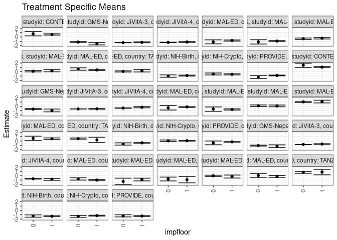

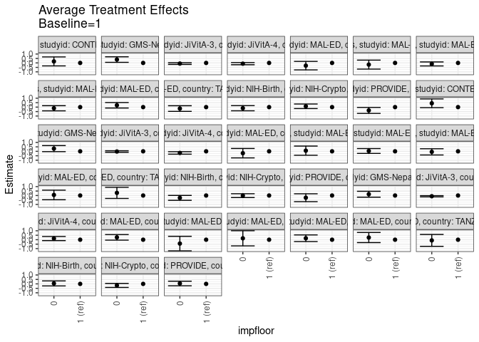

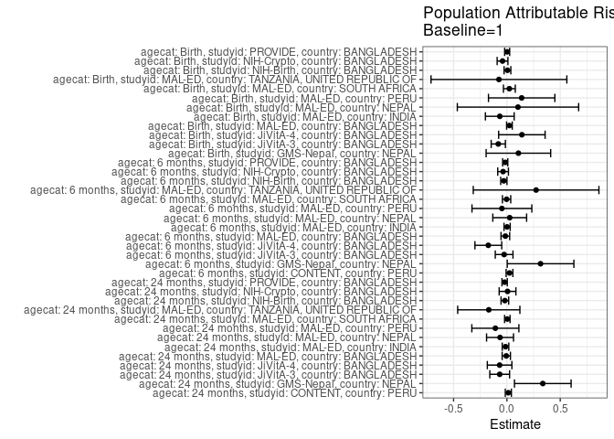

## Results Table

### Parameter: TSM

| agecat | studyid | country | intervention_level | baseline_level | estimate | ci_lower | ci_upper |
| --- | --- | --- | --- | --- | --- | --- | --- |
| Birth | GMS-Nepal | NEPAL | 1 | NA | -1.1937512 | -1.5064230 | -0.8810794 |
| Birth | GMS-Nepal | NEPAL | 0 | NA | -1.0499457 | -1.1596880 | -0.9402034 |
| Birth | JiVitA-3 | BANGLADESH | 1 | NA | -0.6963756 | -0.7644753 | -0.6282759 |
| Birth | JiVitA-3 | BANGLADESH | 0 | NA | -0.7791386 | -0.7992941 | -0.7589831 |
| Birth | JiVitA-4 | BANGLADESH | 1 | NA | -0.8284996 | -1.0525642 | -0.6044350 |
| Birth | JiVitA-4 | BANGLADESH | 0 | NA | -0.6971175 | -0.7578277 | -0.6364073 |
| Birth | MAL-ED | BANGLADESH | 1 | NA | -0.9963759 | -1.1561956 | -0.8365561 |
| Birth | MAL-ED | BANGLADESH | 0 | NA | -0.7345521 | -1.0020299 | -0.4670744 |
| Birth | MAL-ED | INDIA | 1 | NA | -0.8772727 | -1.1935310 | -0.5610144 |
| Birth | MAL-ED | INDIA | 0 | NA | -1.3116667 | -2.0623390 | -0.5609943 |
| Birth | MAL-ED | NEPAL | 1 | NA | -0.9125000 | -1.6413488 | -0.1836512 |
| Birth | MAL-ED | NEPAL | 0 | NA | -0.7568750 | -1.1980753 | -0.3156747 |
| Birth | MAL-ED | PERU | 1 | NA | -0.1851126 | -0.5308770 | 0.1606519 |
| Birth | MAL-ED | PERU | 0 | NA | -0.0208175 | -0.1560196 | 0.1143846 |
| Birth | MAL-ED | SOUTH AFRICA | 1 | NA | -0.1959302 | -0.4617510 | 0.0698905 |
| Birth | MAL-ED | SOUTH AFRICA | 0 | NA | 0.0466667 | -0.4532880 | 0.5466213 |
| Birth | MAL-ED | TANZANIA, UNITED REPUBLIC OF | 1 | NA | 0.8440000 | 0.2094403 | 1.4785597 |
| Birth | MAL-ED | TANZANIA, UNITED REPUBLIC OF | 0 | NA | 0.7655660 | 0.5608207 | 0.9703114 |
| Birth | NIH-Birth | BANGLADESH | 1 | NA | -1.3498801 | -1.4509715 | -1.2487888 |
| Birth | NIH-Birth | BANGLADESH | 0 | NA | -1.2971704 | -1.5617667 | -1.0325741 |
| Birth | NIH-Crypto | BANGLADESH | 1 | NA | -1.2030238 | -1.2980402 | -1.1080075 |
| Birth | NIH-Crypto | BANGLADESH | 0 | NA | -1.3765149 | -1.5794257 | -1.1736040 |
| Birth | PROVIDE | BANGLADESH | 1 | NA | -1.3006285 | -1.3812096 | -1.2200474 |
| Birth | PROVIDE | BANGLADESH | 0 | NA | -1.2561245 | -1.5020145 | -1.0102345 |
| 6 months | CONTENT | PERU | 1 | NA | 1.0402164 | 0.9186858 | 1.1617471 |
| 6 months | CONTENT | PERU | 0 | NA | 1.4706557 | 0.9951116 | 1.9461997 |
| 6 months | GMS-Nepal | NEPAL | 1 | NA | -0.9425895 | -1.2631662 | -0.6220128 |
| 6 months | GMS-Nepal | NEPAL | 0 | NA | -0.6390650 | -0.7472677 | -0.5308623 |
| 6 months | JiVitA-3 | BANGLADESH | 1 | NA | -0.5664665 | -0.6495763 | -0.4833566 |
| 6 months | JiVitA-3 | BANGLADESH | 0 | NA | -0.5907566 | -0.6127773 | -0.5687359 |
| 6 months | JiVitA-4 | BANGLADESH | 1 | NA | -0.2157175 | -0.3443791 | -0.0870560 |
| 6 months | JiVitA-4 | BANGLADESH | 0 | NA | -0.3978421 | -0.4508158 | -0.3448683 |
| 6 months | MAL-ED | BANGLADESH | 1 | NA | -0.1186527 | -0.2530384 | 0.0157329 |
| 6 months | MAL-ED | BANGLADESH | 0 | NA | -0.3298278 | -0.8399546 | 0.1802989 |
| 6 months | MAL-ED | INDIA | 1 | NA | -0.7120612 | -0.8457461 | -0.5783762 |
| 6 months | MAL-ED | INDIA | 0 | NA | -0.6390186 | -1.1366018 | -0.1414354 |
| 6 months | MAL-ED | NEPAL | 1 | NA | 0.1019441 | -0.1037813 | 0.3076694 |
| 6 months | MAL-ED | NEPAL | 0 | NA | 0.1386778 | -0.0408872 | 0.3182427 |
| 6 months | MAL-ED | PERU | 1 | NA | 1.0982559 | 0.7809248 | 1.4155869 |
| 6 months | MAL-ED | PERU | 0 | NA | 1.0363642 | 0.8984793 | 1.1742492 |
| 6 months | MAL-ED | SOUTH AFRICA | 1 | NA | 0.5435511 | 0.3800186 | 0.7070836 |
| 6 months | MAL-ED | SOUTH AFRICA | 0 | NA | 0.6062280 | 0.0967912 | 1.1156648 |
| 6 months | MAL-ED | TANZANIA, UNITED REPUBLIC OF | 1 | NA | 0.2619805 | -0.3474094 | 0.8713705 |
| 6 months | MAL-ED | TANZANIA, UNITED REPUBLIC OF | 0 | NA | 0.5575954 | 0.4224887 | 0.6927022 |
| 6 months | NIH-Birth | BANGLADESH | 1 | NA | -0.4158330 | -0.5124812 | -0.3191848 |
| 6 months | NIH-Birth | BANGLADESH | 0 | NA | -0.6803016 | -0.9375871 | -0.4230161 |
| 6 months | NIH-Crypto | BANGLADESH | 1 | NA | 0.0657117 | -0.0271518 | 0.1585752 |
| 6 months | NIH-Crypto | BANGLADESH | 0 | NA | 0.0494489 | -0.1432532 | 0.2421511 |
| 6 months | PROVIDE | BANGLADESH | 1 | NA | -0.1832245 | -0.2708421 | -0.0956068 |
| 6 months | PROVIDE | BANGLADESH | 0 | NA | -0.4305278 | -0.8638564 | 0.0028008 |
| 24 months | CONTENT | PERU | 1 | NA | 0.5767951 | 0.4362198 | 0.7173704 |
| 24 months | CONTENT | PERU | 0 | NA | 0.7469606 | 0.2628017 | 1.2311195 |
| 24 months | GMS-Nepal | NEPAL | 1 | NA | -1.5353933 | -1.8132891 | -1.2574974 |
| 24 months | GMS-Nepal | NEPAL | 0 | NA | -1.1591260 | -1.2931805 | -1.0250715 |
| 24 months | JiVitA-3 | BANGLADESH | 1 | NA | -1.2293286 | -1.3259704 | -1.1326867 |
| 24 months | JiVitA-3 | BANGLADESH | 0 | NA | -1.2994288 | -1.3245371 | -1.2743205 |
| 24 months | JiVitA-4 | BANGLADESH | 1 | NA | -1.1547105 | -1.2709629 | -1.0384581 |
| 24 months | JiVitA-4 | BANGLADESH | 0 | NA | -1.2373390 | -1.2754705 | -1.1992076 |
| 24 months | MAL-ED | BANGLADESH | 1 | NA | -0.8134121 | -0.9398808 | -0.6869434 |
| 24 months | MAL-ED | BANGLADESH | 0 | NA | -1.1197414 | -1.5784934 | -0.6609894 |
| 24 months | MAL-ED | INDIA | 1 | NA | -0.9384280 | -1.0580706 | -0.8187853 |
| 24 months | MAL-ED | INDIA | 0 | NA | -1.1268505 | -1.6162574 | -0.6374435 |
| 24 months | MAL-ED | NEPAL | 1 | NA | -0.2827097 | -0.4538353 | -0.1115840 |
| 24 months | MAL-ED | NEPAL | 0 | NA | -0.3969013 | -0.5485493 | -0.2452533 |
| 24 months | MAL-ED | PERU | 1 | NA | 0.2195116 | -0.0346556 | 0.4736787 |
| 24 months | MAL-ED | PERU | 0 | NA | 0.0904244 | -0.0497198 | 0.2305685 |
| 24 months | MAL-ED | SOUTH AFRICA | 1 | NA | 0.4052666 | 0.2762662 | 0.5342669 |
| 24 months | MAL-ED | SOUTH AFRICA | 0 | NA | 0.6125257 | 0.3373754 | 0.8876759 |
| 24 months | MAL-ED | TANZANIA, UNITED REPUBLIC OF | 1 | NA | 0.2177888 | -0.0657243 | 0.5013018 |
| 24 months | MAL-ED | TANZANIA, UNITED REPUBLIC OF | 0 | NA | 0.0579074 | -0.0736547 | 0.1894694 |
| 24 months | NIH-Birth | BANGLADESH | 1 | NA | -0.8914215 | -0.9966888 | -0.7861541 |
| 24 months | NIH-Birth | BANGLADESH | 0 | NA | -1.0131628 | -1.2852774 | -0.7410482 |
| 24 months | NIH-Crypto | BANGLADESH | 1 | NA | -0.6161943 | -0.7401006 | -0.4922880 |
| 24 months | NIH-Crypto | BANGLADESH | 0 | NA | -0.5230079 | -0.7484628 | -0.2975531 |
| 24 months | PROVIDE | BANGLADESH | 1 | NA | -0.8712794 | -0.9570734 | -0.7854854 |
| 24 months | PROVIDE | BANGLADESH | 0 | NA | -1.2416459 | -1.5673152 | -0.9159766 |

### Parameter: E(Y)

| agecat | studyid | country | intervention_level | baseline_level | estimate | ci_lower | ci_upper |
| --- | --- | --- | --- | --- | --- | --- | --- |
| Birth | GMS-Nepal | NEPAL | NA | NA | -1.0860636 | -1.1830454 | -0.9890818 |
| Birth | JiVitA-3 | BANGLADESH | NA | NA | -0.7773511 | -0.7963777 | -0.7583245 |
| Birth | JiVitA-4 | BANGLADESH | NA | NA | -0.6882498 | -0.7406539 | -0.6358456 |
| Birth | MAL-ED | BANGLADESH | NA | NA | -0.9728358 | -1.1217009 | -0.8239707 |
| Birth | MAL-ED | INDIA | NA | NA | -0.9441026 | -1.2397919 | -0.6484132 |
| Birth | MAL-ED | NEPAL | NA | NA | -0.8087500 | -1.1914221 | -0.4260779 |
| Birth | MAL-ED | PERU | NA | NA | -0.0468095 | -0.1738806 | 0.0802616 |
| Birth | MAL-ED | SOUTH AFRICA | NA | NA | -0.1729474 | -0.4186222 | 0.0727275 |
| Birth | MAL-ED | TANZANIA, UNITED REPUBLIC OF | NA | NA | 0.7690991 | 0.5714748 | 0.9667234 |
| Birth | NIH-Birth | BANGLADESH | NA | NA | -1.3448514 | -1.4396716 | -1.2500312 |
| Birth | NIH-Crypto | BANGLADESH | NA | NA | -1.2441513 | -1.3281130 | -1.1601897 |
| Birth | PROVIDE | BANGLADESH | NA | NA | -1.2984586 | -1.3752758 | -1.2216415 |
| 6 months | CONTENT | PERU | NA | NA | 1.0644279 | 0.9468682 | 1.1819876 |
| 6 months | GMS-Nepal | NEPAL | NA | NA | -0.6273772 | -0.7253868 | -0.5293676 |
| 6 months | JiVitA-3 | BANGLADESH | NA | NA | -0.5926720 | -0.6122891 | -0.5730549 |
| 6 months | JiVitA-4 | BANGLADESH | NA | NA | -0.3901347 | -0.4273932 | -0.3528762 |
| 6 months | MAL-ED | BANGLADESH | NA | NA | -0.1333333 | -0.2623761 | -0.0042906 |
| 6 months | MAL-ED | INDIA | NA | NA | -0.7102872 | -0.8371659 | -0.5834085 |
| 6 months | MAL-ED | NEPAL | NA | NA | 0.1281441 | -0.0056126 | 0.2619008 |
| 6 months | MAL-ED | PERU | NA | NA | 1.0512099 | 0.9285617 | 1.1738581 |
| 6 months | MAL-ED | SOUTH AFRICA | NA | NA | 0.5404351 | 0.3867005 | 0.6941696 |
| 6 months | MAL-ED | TANZANIA, UNITED REPUBLIC OF | NA | NA | 0.5355782 | 0.4032519 | 0.6679046 |
| 6 months | NIH-Birth | BANGLADESH | NA | NA | -0.4447399 | -0.5354039 | -0.3540758 |
| 6 months | NIH-Crypto | BANGLADESH | NA | NA | 0.0297622 | -0.0491685 | 0.1086930 |
| 6 months | PROVIDE | BANGLADESH | NA | NA | -0.1990907 | -0.2817968 | -0.1163845 |
| 24 months | CONTENT | PERU | NA | NA | 0.5902439 | 0.4560143 | 0.7244735 |
| 24 months | GMS-Nepal | NEPAL | NA | NA | -1.1990840 | -1.3039914 | -1.0941766 |
| 24 months | JiVitA-3 | BANGLADESH | NA | NA | -1.2970420 | -1.3203145 | -1.2737694 |
| 24 months | JiVitA-4 | BANGLADESH | NA | NA | -1.2232311 | -1.2550891 | -1.1913732 |
| 24 months | MAL-ED | BANGLADESH | NA | NA | -0.8192925 | -0.9412667 | -0.6973182 |
| 24 months | MAL-ED | INDIA | NA | NA | -0.9516520 | -1.0670654 | -0.8362385 |
| 24 months | MAL-ED | NEPAL | NA | NA | -0.3471493 | -0.4618867 | -0.2324120 |
| 24 months | MAL-ED | PERU | NA | NA | 0.1111982 | -0.0118399 | 0.2342362 |
| 24 months | MAL-ED | SOUTH AFRICA | NA | NA | 0.4090301 | 0.2879441 | 0.5301161 |
| 24 months | MAL-ED | TANZANIA, UNITED REPUBLIC OF | NA | NA | 0.0477437 | -0.0779935 | 0.1734809 |
| 24 months | NIH-Birth | BANGLADESH | NA | NA | -0.9106710 | -1.0090143 | -0.8123277 |
| 24 months | NIH-Crypto | BANGLADESH | NA | NA | -0.6103502 | -0.7050157 | -0.5156847 |
| 24 months | PROVIDE | BANGLADESH | NA | NA | -0.8928670 | -0.9755153 | -0.8102187 |

### Parameter: ATE

| agecat | studyid | country | intervention_level | baseline_level | estimate | ci_lower | ci_upper |
| --- | --- | --- | --- | --- | --- | --- | --- |
| Birth | GMS-Nepal | NEPAL | 1 | 1 | 0.0000000 | 0.0000000 | 0.0000000 |
| Birth | GMS-Nepal | NEPAL | 0 | 1 | 0.1438055 | -0.1870562 | 0.4746673 |
| Birth | JiVitA-3 | BANGLADESH | 1 | 1 | 0.0000000 | 0.0000000 | 0.0000000 |
| Birth | JiVitA-3 | BANGLADESH | 0 | 1 | -0.0827630 | -0.1531822 | -0.0123438 |
| Birth | JiVitA-4 | BANGLADESH | 1 | 1 | 0.0000000 | 0.0000000 | 0.0000000 |
| Birth | JiVitA-4 | BANGLADESH | 0 | 1 | 0.1313821 | -0.0995447 | 0.3623089 |
| Birth | MAL-ED | BANGLADESH | 1 | 1 | 0.0000000 | 0.0000000 | 0.0000000 |
| Birth | MAL-ED | BANGLADESH | 0 | 1 | 0.2618238 | -0.0506431 | 0.5742907 |
| Birth | MAL-ED | INDIA | 1 | 1 | 0.0000000 | 0.0000000 | 0.0000000 |
| Birth | MAL-ED | INDIA | 0 | 1 | -0.4343939 | -1.2489664 | 0.3801785 |
| Birth | MAL-ED | NEPAL | 1 | 1 | 0.0000000 | 0.0000000 | 0.0000000 |
| Birth | MAL-ED | NEPAL | 0 | 1 | 0.1556250 | -0.6963599 | 1.0076099 |
| Birth | MAL-ED | PERU | 1 | 1 | 0.0000000 | 0.0000000 | 0.0000000 |
| Birth | MAL-ED | PERU | 0 | 1 | 0.1642950 | -0.2077770 | 0.5363671 |
| Birth | MAL-ED | SOUTH AFRICA | 1 | 1 | 0.0000000 | 0.0000000 | 0.0000000 |
| Birth | MAL-ED | SOUTH AFRICA | 0 | 1 | 0.2425969 | -0.3236321 | 0.8088259 |
| Birth | MAL-ED | TANZANIA, UNITED REPUBLIC OF | 1 | 1 | 0.0000000 | 0.0000000 | 0.0000000 |
| Birth | MAL-ED | TANZANIA, UNITED REPUBLIC OF | 0 | 1 | -0.0784340 | -0.7452073 | 0.5883394 |
| Birth | NIH-Birth | BANGLADESH | 1 | 1 | 0.0000000 | 0.0000000 | 0.0000000 |
| Birth | NIH-Birth | BANGLADESH | 0 | 1 | 0.0527097 | -0.2298421 | 0.3352615 |
| Birth | NIH-Crypto | BANGLADESH | 1 | 1 | 0.0000000 | 0.0000000 | 0.0000000 |
| Birth | NIH-Crypto | BANGLADESH | 0 | 1 | -0.1734910 | -0.3988182 | 0.0518362 |
| Birth | PROVIDE | BANGLADESH | 1 | 1 | 0.0000000 | 0.0000000 | 0.0000000 |
| Birth | PROVIDE | BANGLADESH | 0 | 1 | 0.0445040 | -0.2138047 | 0.3028128 |
| 6 months | CONTENT | PERU | 1 | 1 | 0.0000000 | 0.0000000 | 0.0000000 |
| 6 months | CONTENT | PERU | 0 | 1 | 0.4304392 | -0.0607649 | 0.9216433 |
| 6 months | GMS-Nepal | NEPAL | 1 | 1 | 0.0000000 | 0.0000000 | 0.0000000 |
| 6 months | GMS-Nepal | NEPAL | 0 | 1 | 0.3035245 | -0.0358283 | 0.6428772 |
| 6 months | JiVitA-3 | BANGLADESH | 1 | 1 | 0.0000000 | 0.0000000 | 0.0000000 |
| 6 months | JiVitA-3 | BANGLADESH | 0 | 1 | -0.0242901 | -0.1107404 | 0.0621602 |
| 6 months | JiVitA-4 | BANGLADESH | 1 | 1 | 0.0000000 | 0.0000000 | 0.0000000 |
| 6 months | JiVitA-4 | BANGLADESH | 0 | 1 | -0.1821245 | -0.3204758 | -0.0437733 |
| 6 months | MAL-ED | BANGLADESH | 1 | 1 | 0.0000000 | 0.0000000 | 0.0000000 |
| 6 months | MAL-ED | BANGLADESH | 0 | 1 | -0.2111751 | -0.7393507 | 0.3170005 |
| 6 months | MAL-ED | INDIA | 1 | 1 | 0.0000000 | 0.0000000 | 0.0000000 |
| 6 months | MAL-ED | INDIA | 0 | 1 | 0.0730425 | -0.4426003 | 0.5886853 |
| 6 months | MAL-ED | NEPAL | 1 | 1 | 0.0000000 | 0.0000000 | 0.0000000 |
| 6 months | MAL-ED | NEPAL | 0 | 1 | 0.0367337 | -0.2364569 | 0.3099243 |
| 6 months | MAL-ED | PERU | 1 | 1 | 0.0000000 | 0.0000000 | 0.0000000 |
| 6 months | MAL-ED | PERU | 0 | 1 | -0.0618916 | -0.4116777 | 0.2878944 |
| 6 months | MAL-ED | SOUTH AFRICA | 1 | 1 | 0.0000000 | 0.0000000 | 0.0000000 |
| 6 months | MAL-ED | SOUTH AFRICA | 0 | 1 | 0.0626770 | -0.4756576 | 0.6010115 |
| 6 months | MAL-ED | TANZANIA, UNITED REPUBLIC OF | 1 | 1 | 0.0000000 | 0.0000000 | 0.0000000 |
| 6 months | MAL-ED | TANZANIA, UNITED REPUBLIC OF | 0 | 1 | 0.2956149 | -0.3284723 | 0.9197021 |
| 6 months | NIH-Birth | BANGLADESH | 1 | 1 | 0.0000000 | 0.0000000 | 0.0000000 |
| 6 months | NIH-Birth | BANGLADESH | 0 | 1 | -0.2644686 | -0.5390179 | 0.0100807 |
| 6 months | NIH-Crypto | BANGLADESH | 1 | 1 | 0.0000000 | 0.0000000 | 0.0000000 |
| 6 months | NIH-Crypto | BANGLADESH | 0 | 1 | -0.0162628 | -0.2305102 | 0.1979846 |
| 6 months | PROVIDE | BANGLADESH | 1 | 1 | 0.0000000 | 0.0000000 | 0.0000000 |
| 6 months | PROVIDE | BANGLADESH | 0 | 1 | -0.2473033 | -0.6901021 | 0.1954955 |
| 24 months | CONTENT | PERU | 1 | 1 | 0.0000000 | 0.0000000 | 0.0000000 |
| 24 months | CONTENT | PERU | 0 | 1 | 0.1701655 | -0.3339526 | 0.6742836 |
| 24 months | GMS-Nepal | NEPAL | 1 | 1 | 0.0000000 | 0.0000000 | 0.0000000 |
| 24 months | GMS-Nepal | NEPAL | 0 | 1 | 0.3762672 | 0.0666011 | 0.6859333 |
| 24 months | JiVitA-3 | BANGLADESH | 1 | 1 | 0.0000000 | 0.0000000 | 0.0000000 |
| 24 months | JiVitA-3 | BANGLADESH | 0 | 1 | -0.0701002 | -0.1667949 | 0.0265944 |
| 24 months | JiVitA-4 | BANGLADESH | 1 | 1 | 0.0000000 | 0.0000000 | 0.0000000 |
| 24 months | JiVitA-4 | BANGLADESH | 0 | 1 | -0.0826285 | -0.2048090 | 0.0395521 |
| 24 months | MAL-ED | BANGLADESH | 1 | 1 | 0.0000000 | 0.0000000 | 0.0000000 |
| 24 months | MAL-ED | BANGLADESH | 0 | 1 | -0.3063293 | -0.7835142 | 0.1708555 |
| 24 months | MAL-ED | INDIA | 1 | 1 | 0.0000000 | 0.0000000 | 0.0000000 |
| 24 months | MAL-ED | INDIA | 0 | 1 | -0.1884225 | -0.6929338 | 0.3160889 |
| 24 months | MAL-ED | NEPAL | 1 | 1 | 0.0000000 | 0.0000000 | 0.0000000 |
| 24 months | MAL-ED | NEPAL | 0 | 1 | -0.1141916 | -0.3395133 | 0.1111301 |
| 24 months | MAL-ED | PERU | 1 | 1 | 0.0000000 | 0.0000000 | 0.0000000 |
| 24 months | MAL-ED | PERU | 0 | 1 | -0.1290872 | -0.4189218 | 0.1607474 |
| 24 months | MAL-ED | SOUTH AFRICA | 1 | 1 | 0.0000000 | 0.0000000 | 0.0000000 |
| 24 months | MAL-ED | SOUTH AFRICA | 0 | 1 | 0.2072591 | -0.0998149 | 0.5143331 |
| 24 months | MAL-ED | TANZANIA, UNITED REPUBLIC OF | 1 | 1 | 0.0000000 | 0.0000000 | 0.0000000 |
| 24 months | MAL-ED | TANZANIA, UNITED REPUBLIC OF | 0 | 1 | -0.1598814 | -0.4753741 | 0.1556113 |
| 24 months | NIH-Birth | BANGLADESH | 1 | 1 | 0.0000000 | 0.0000000 | 0.0000000 |
| 24 months | NIH-Birth | BANGLADESH | 0 | 1 | -0.1217414 | -0.4136157 | 0.1701329 |
| 24 months | NIH-Crypto | BANGLADESH | 1 | 1 | 0.0000000 | 0.0000000 | 0.0000000 |
| 24 months | NIH-Crypto | BANGLADESH | 0 | 1 | 0.0931864 | -0.1620629 | 0.3484357 |
| 24 months | PROVIDE | BANGLADESH | 1 | 1 | 0.0000000 | 0.0000000 | 0.0000000 |
| 24 months | PROVIDE | BANGLADESH | 0 | 1 | -0.3703665 | -0.7070851 | -0.0336480 |

### Parameter: PAR

| agecat | studyid | country | intervention_level | baseline_level | estimate | ci_lower | ci_upper |
| --- | --- | --- | --- | --- | --- | --- | --- |
| Birth | GMS-Nepal | NEPAL | 1 | NA | 0.1076876 | -0.1948442 | 0.4102193 |
| Birth | JiVitA-3 | BANGLADESH | 1 | NA | -0.0809755 | -0.1476529 | -0.0142981 |
| Birth | JiVitA-4 | BANGLADESH | 1 | NA | 0.1402498 | -0.0775635 | 0.3580632 |
| Birth | MAL-ED | BANGLADESH | 1 | NA | 0.0235401 | -0.0028888 | 0.0499689 |
| Birth | MAL-ED | INDIA | 1 | NA | -0.0668298 | -0.2016929 | 0.0680332 |
| Birth | MAL-ED | NEPAL | 1 | NA | 0.1037500 | -0.4650307 | 0.6725307 |
| Birth | MAL-ED | PERU | 1 | NA | 0.1383030 | -0.1729111 | 0.4495172 |
| Birth | MAL-ED | SOUTH AFRICA | 1 | NA | 0.0229829 | -0.0325492 | 0.0785150 |
| Birth | MAL-ED | TANZANIA, UNITED REPUBLIC OF | 1 | NA | -0.0749009 | -0.7116467 | 0.5618449 |
| Birth | NIH-Birth | BANGLADESH | 1 | NA | 0.0050287 | -0.0265747 | 0.0366322 |
| Birth | NIH-Crypto | BANGLADESH | 1 | NA | -0.0411275 | -0.0916794 | 0.0094243 |
| Birth | PROVIDE | BANGLADESH | 1 | NA | 0.0021699 | -0.0212605 | 0.0256002 |
| 6 months | CONTENT | PERU | 1 | NA | 0.0242115 | -0.0074794 | 0.0559023 |
| 6 months | GMS-Nepal | NEPAL | 1 | NA | 0.3152123 | 0.0027475 | 0.6276771 |
| 6 months | JiVitA-3 | BANGLADESH | 1 | NA | -0.0262055 | -0.1091704 | 0.0567593 |
| 6 months | JiVitA-4 | BANGLADESH | 1 | NA | -0.1744172 | -0.2999734 | -0.0488609 |
| 6 months | MAL-ED | BANGLADESH | 1 | NA | -0.0146806 | -0.0552256 | 0.0258644 |
| 6 months | MAL-ED | INDIA | 1 | NA | 0.0017739 | -0.0271877 | 0.0307355 |
| 6 months | MAL-ED | NEPAL | 1 | NA | 0.0262000 | -0.1322529 | 0.1846530 |
| 6 months | MAL-ED | PERU | 1 | NA | -0.0470460 | -0.3275361 | 0.2334441 |
| 6 months | MAL-ED | SOUTH AFRICA | 1 | NA | -0.0031160 | -0.0418626 | 0.0356307 |
| 6 months | MAL-ED | TANZANIA, UNITED REPUBLIC OF | 1 | NA | 0.2735977 | -0.3154019 | 0.8625973 |
| 6 months | NIH-Birth | BANGLADESH | 1 | NA | -0.0289069 | -0.0582349 | 0.0004212 |
| 6 months | NIH-Crypto | BANGLADESH | 1 | NA | -0.0359495 | -0.0861566 | 0.0142576 |
| 6 months | PROVIDE | BANGLADESH | 1 | NA | -0.0158662 | -0.0399236 | 0.0081913 |
| 24 months | CONTENT | PERU | 1 | NA | 0.0134488 | -0.0150895 | 0.0419870 |
| 24 months | GMS-Nepal | NEPAL | 1 | NA | 0.3363093 | 0.0707865 | 0.6018320 |
| 24 months | JiVitA-3 | BANGLADESH | 1 | NA | -0.0677134 | -0.1604130 | 0.0249862 |
| 24 months | JiVitA-4 | BANGLADESH | 1 | NA | -0.0685206 | -0.1836352 | 0.0465940 |
| 24 months | MAL-ED | BANGLADESH | 1 | NA | -0.0058804 | -0.0446971 | 0.0329363 |
| 24 months | MAL-ED | INDIA | 1 | NA | -0.0132240 | -0.0439184 | 0.0174704 |
| 24 months | MAL-ED | NEPAL | 1 | NA | -0.0644397 | -0.1907440 | 0.0618647 |
| 24 months | MAL-ED | PERU | 1 | NA | -0.1083134 | -0.3288376 | 0.1122108 |
| 24 months | MAL-ED | SOUTH AFRICA | 1 | NA | 0.0037635 | -0.0217883 | 0.0293153 |
| 24 months | MAL-ED | TANZANIA, UNITED REPUBLIC OF | 1 | NA | -0.1700451 | -0.4616843 | 0.1215942 |
| 24 months | NIH-Birth | BANGLADESH | 1 | NA | -0.0192495 | -0.0551099 | 0.0166109 |
| 24 months | NIH-Crypto | BANGLADESH | 1 | NA | 0.0058441 | -0.0726121 | 0.0843004 |
| 24 months | PROVIDE | BANGLADESH | 1 | NA | -0.0215876 | -0.0464579 | 0.0032826 |